# Community Ecology Basics

Nilanjan Chatterjee

30 October 2019

## Nestedness

Nestedness is a measure of structure in an ecological system. There are different measures for nestedness. One common measure is calculating the temperature. We will use that measure to calculate nestedness here. The value ranges from 0-100 where 0 stands for perfectly nested community and 100 stands for random community

Vegan is one the most important library for analysis of community dataset. The most common type of community data is sites x species data. We would uploda a dummy dataset in the system and leran how to calculate nestedness.

## Import the data in R

```r
library(vegan)
setwd("C:/Users/HP/Documents/com_eco")
bhagbird <-read.csv("allbird_38.csv")
head(bhagbird)
```

```
##             SITE..500.m.. WCR PWR WW WBW GW BD CK WTK RL I BWT SF LF LC
## 1            Triveni ghat   0   1  0   1  0  0  1   1  1 0   1  0  0  1
## 2                  Ghat 1   0   1  0   1  1  0  0   1  1 0   1  0  0  1
## 3                  Ghat 2   0   1  0   1  1  0  1   0  0 0   1  0  0  1
## 4                Ramjhula   0   0  0   1  0  0  1   1  1 0   1  0  0  0
## 5  Phoolchatti main river   1   1  0   1  1  1  1   0  0 0   1  0  0  1
## 6 Phoolchatti side stream   1   1  0   1  1  1  1   1  0 0   1  1  1  1
```

## Calculating nestedness

```r
nesttry<-nestedtemp(bhagbird[,2:15])
nesttry
```

```
## nestedness temperature: 17.81374
## with matrix fill 0.4450549
```

## Including Plots

The plots for nestedness temperature is given by Darker the colour means higher the probability of the species extinction from the site

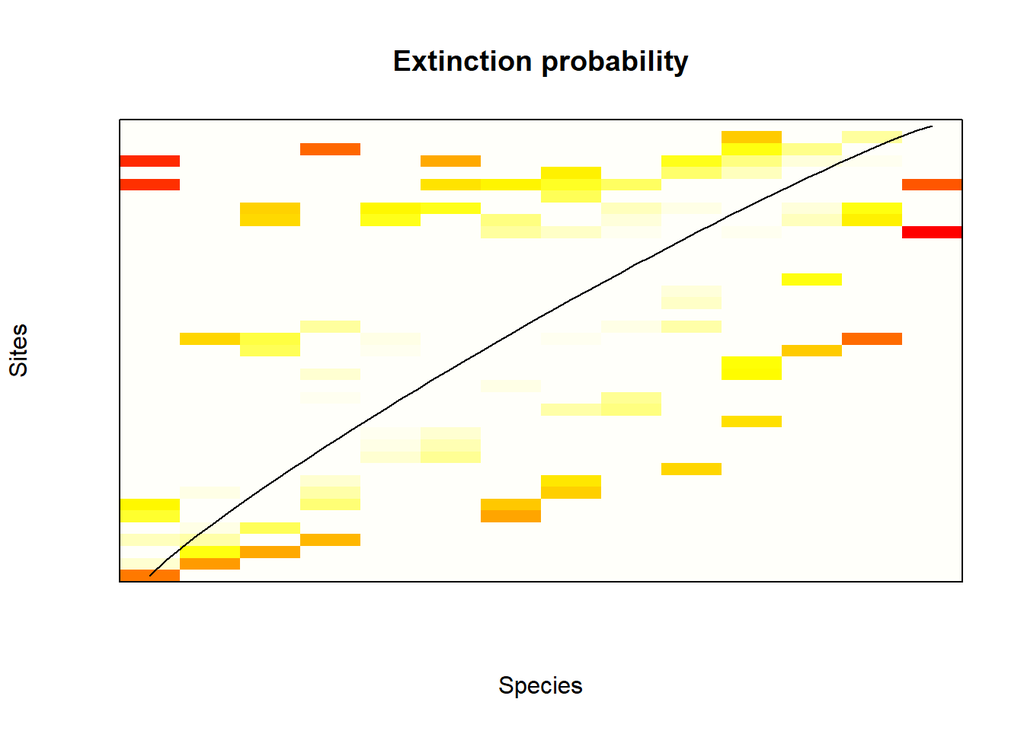

```r
plot(nesttry, xlab = "Species", ylab="Sites",main="Extinction probability")
```

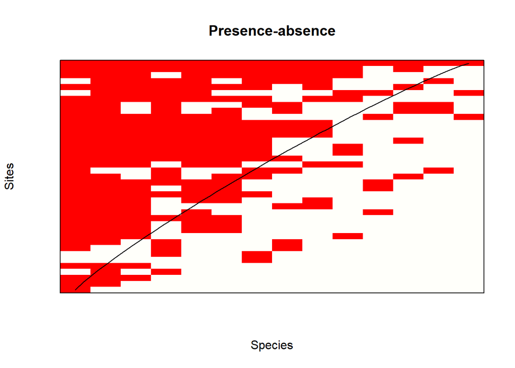

```r
plot(nesttry, kind="incidence",xlab = "Species", ylab="Sites",main="Presence-absence")
```

## Beta-diversity

Similar to nestedness, there is another measure to understand the turnover of species in different community. The measure is known as Beta-diversity. We would use the package betapart for calculation of beta-diversity

```r
library(betapart)
spr_14 <-read.csv("spring_14.csv")
head(spr_14)
```

```
##                         X  X.1 Phalacrocorax_niger Vanellus_duvaucelii
## 1            Triveni ghat 2014                   1                   1
## 2                  Ghat 1 2014                   1                   1
## 3                  Ghat 2 2014                   1                   0
## 4                Ramjhula 2014                   0                   1
## 5  Phoolchatti main river 2014                   1                   0
## 6 Phoolchatti side stream 2014                   1                   0
##   Ibidorhyncha_struthersii Actitis_hypoleucos Cinclus_pallasii
## 1                        0                  0                0
## 2                        0                  0                0
## 3                        0                  0                0
## 4                        0                  0                0
## 5                        0                  0                0
## 6                        0                  0                1
##   Enicurus_scouleri Enicurus_maculatus Myophonus_caeruleus
```

[output cut: 27 more lines]

## Beta-diversity calculation using abundance data

```r
beta.try <-beta.pair.abund(spr_14[,3:18])
beta_abd <- as.matrix(beta.try$beta.bray)
beta_abd[upper.tri(beta_abd, diag = FALSE)] <- ""
head(beta_abd)
```

```
##   1                   2                   3
## 1 "0"                 ""                  ""
## 2 "0.333333333333333" "0"                 ""
## 3 "0.333333333333333" "0.5"               "0"
## 4 "0.333333333333333" "0.454545454545455" "0.636363636363636"
## 5 "0.454545454545455" "0.428571428571429" "0.142857142857143"
## 6 "0.368421052631579" "0.6"               "0.466666666666667"
##   4                   5                   6   7  8  9  10 11 12 13 14 15
## 1 ""                  ""                  ""  "" "" "" "" "" "" "" "" ""
## 2 ""                  ""                  ""  "" "" "" "" "" "" "" "" ""
## 3 ""                  ""                  ""  "" "" "" "" "" "" "" "" ""
## 4 "0"                 ""                  ""  "" "" "" "" "" "" "" "" ""
## 5 "0.6"               "0"                 ""  "" "" "" "" "" "" "" "" ""
## 6 "0.666666666666667" "0.571428571428571" "0" "" "" "" "" "" "" "" "" ""
##   16 17 18 19 20 21 22 23 24 25 26 27 28 29 30 31 32 33 34 35 36 37 38 39
## 1 "" "" "" "" "" "" "" "" "" "" "" "" "" "" "" "" "" "" "" "" "" "" "" ""
## 2 "" "" "" "" "" "" "" "" "" "" "" "" "" "" "" "" "" "" "" "" "" "" "" ""
## 3 "" "" "" "" "" "" "" "" "" "" "" "" "" "" "" "" "" "" "" "" "" "" "" ""
## 4 "" "" "" "" "" "" "" "" "" "" "" "" "" "" "" "" "" "" "" "" "" "" "" ""
## 5 "" "" "" "" "" "" "" "" "" "" "" "" "" "" "" "" "" "" "" "" "" "" "" ""
## 6 "" "" "" "" "" "" "" "" "" "" "" "" "" "" "" "" "" "" "" "" "" "" "" ""
##   40 41 42 43
## 1 "" "" "" ""
## 2 "" "" "" ""
## 3 "" "" "" ""
## 4 "" "" "" ""
## 5 "" "" "" ""
## 6 "" "" "" ""
```

## Beta-diversity calculation using presence-absence data

```r
spr_14_pa <-spr_14
spr_14_pa[spr_14_pa > 0] <-1
class(spr_14_pa)
```

```
## [1] "data.frame"
```

```r
beta.try.pa <-beta.pair(spr_14_pa[,3:18])
beta_pa <- as.matrix(beta.try.pa$beta.sor)
beta_pa[upper.tri(beta_pa, diag = FALSE)] <- ""
head(beta_pa)
```

```
##   1                   2                   3
## 1 "0"                 ""                  ""
## 2 "0.2"               "0"                 ""
## 3 "0.2"               "0.5"               "0"
## 4 "0.2"               "0.25"              "0.5"
## 5 "0.333333333333333" "0.428571428571429" "0.142857142857143"
## 6 "0.230769230769231" "0.454545454545455" "0.272727272727273"
##   4                   5     6   7  8  9  10 11 12 13 14 15 16 17 18 19 20
## 1 ""                  ""    ""  "" "" "" "" "" "" "" "" "" "" "" "" "" ""
## 2 ""                  ""    ""  "" "" "" "" "" "" "" "" "" "" "" "" "" ""
## 3 ""                  ""    ""  "" "" "" "" "" "" "" "" "" "" "" "" "" ""
## 4 "0"                 ""    ""  "" "" "" "" "" "" "" "" "" "" "" "" "" ""
## 5 "0.428571428571429" "0"   ""  "" "" "" "" "" "" "" "" "" "" "" "" "" ""
## 6 "0.454545454545455" "0.4" "0" "" "" "" "" "" "" "" "" "" "" "" "" "" ""
##   21 22 23 24 25 26 27 28 29 30 31 32 33 34 35 36 37 38 39 40 41 42 43
## 1 "" "" "" "" "" "" "" "" "" "" "" "" "" "" "" "" "" "" "" "" "" "" ""
## 2 "" "" "" "" "" "" "" "" "" "" "" "" "" "" "" "" "" "" "" "" "" "" ""
## 3 "" "" "" "" "" "" "" "" "" "" "" "" "" "" "" "" "" "" "" "" "" "" ""
## 4 "" "" "" "" "" "" "" "" "" "" "" "" "" "" "" "" "" "" "" "" "" "" ""
## 5 "" "" "" "" "" "" "" "" "" "" "" "" "" "" "" "" "" "" "" "" "" "" ""
## 6 "" "" "" "" "" "" "" "" "" "" "" "" "" "" "" "" "" "" "" "" "" "" ""
```

## Reference

Almeida-Neto, M., Guimar?es, P., Guimar?es, P.R., Loyola, R.D. & Ulrich, W. (2008). A consistent metric for nestedness analysis in ecological systems: reconciling concept and measurement. Oikos 117, 1227-1239.

Almeida-Neto, M. & Ulrich, W. (2011). A straightforward computational approach for measuring nestedness using quantitative matrices. Env. Mod. Software 26, 173-178.

Atmar, W. & Patterson, B.D. (1993). The measurement of order and disorder in the distribution of species in fragmented habitat. Oecologia 96, 373-382.

Baselga, A. (2012). The relationship between species replacement, dissimilarity derived from nestedness, and nestedness. Global Ecol. Biogeogr. 21, 1223-1232.

Brualdi, R.A. & Sanderson, J.G. (1999). Nested species subsets, gaps, and discrepancy. Oecologia 119, 256-264.

Patterson, B.D. & Atmar, W. (1986). Nested subsets and the structure of insular mammalian faunas and archipelagos. Biol. J. Linnean Soc. 28, 65-82.

Rodr?guez-Giron?s, M.A. & Santamaria, L. (2006). A new algorithm to calculate the nestedness temperature of presence-absence matrices. J. Biogeogr. 33, 924-935.

Stone, L. & Roberts, A. (1990). The checkerboard score and species distributions. Oecologia 85, 74-79.

Wright, D.H., Patterson, B.D., Mikkelson, G.M., Cutler, A. & Atmar, W. (1998). A comparative analysis of nested subset patterns of species composition. Oecologia 113, 1-20.